# Submission Phenology Modelling

Patricia Helpap

2023-11-10

### Exercise 1 - Optimization Methods

*The following describes, how the phenology model implemented in Chapter 6 from `A Handful of Pixels` can be optimized using three different methods:*

1. The model could be optimized by using more than one station as input data for the model i.e. improve calibration parameters. This would increase the number of observations that are used to calculate the optimal parameters used in the model and should therefore make predictions more robust. *This method will be implemented in this report.*
2. One could also implement a different parameter opitimization method instead of simulated annealing, such as Bayesian optimization e.g. through `{Bayesian Tools}`.
3. A third method to potentially improve the model is to increase the number of parameters that are taken into the model. These should be based on a physical understanding of the driving factors of phenology.

### Exercise 2 - Implementation of Optimization Proposal 1)

library setup:

```r
library(here)
library(phenocamr)
library(tidyverse)
library(GenSA)
library(geodata)
library(dplyr)
library(ggplot2)
library(ggpubr)
library(patchwork)
library(daymetr)
library(leaflet)
library(MODISTools)
library(tidyterra)
library(reshape2)
```

Downloading greenness time series of the original Harvard station (+ two further sites that are closest to harvard to enhance *n* and improve the optimization parameters) and calculating phenology (phenophases).

The chosen sites are:

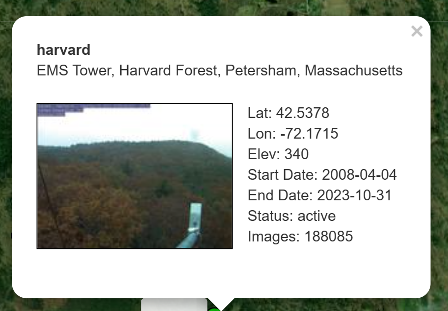

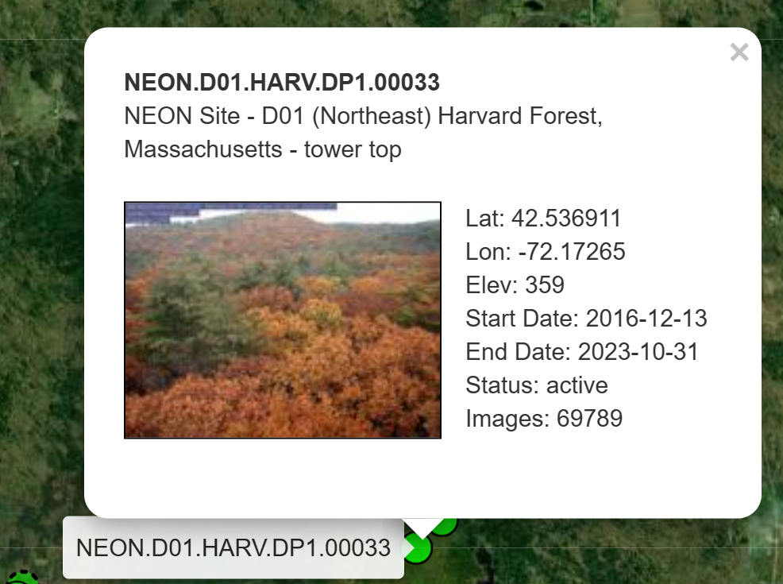

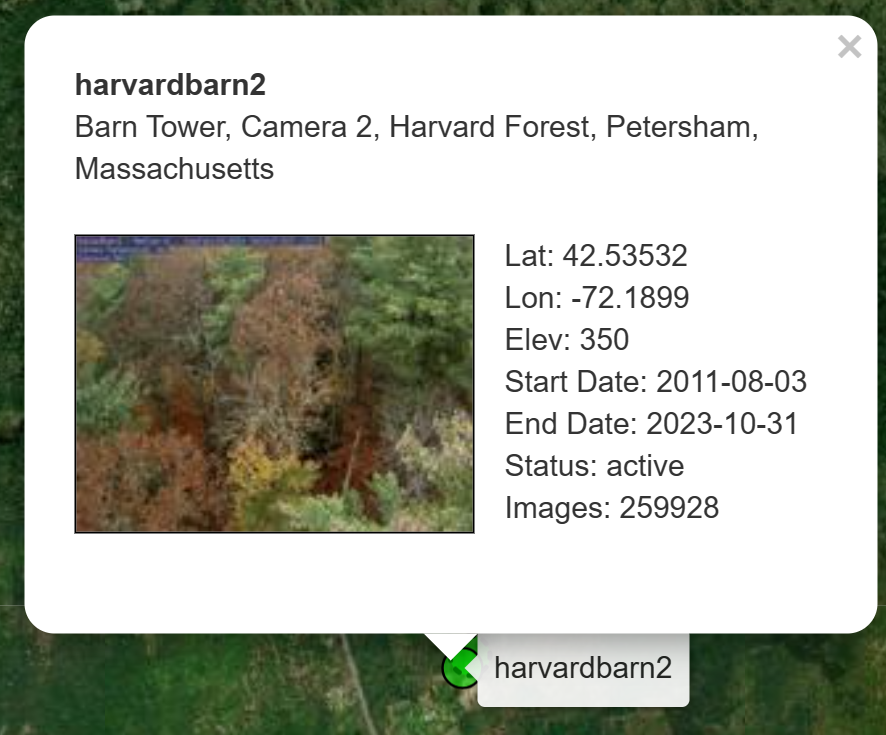

Downloading phenology data for the chosen sites:

```r
phenocamr::download_phenocam(
  site = "harvard$",
  veg_type = "DB",
  roi_id = "1000",
  daymet = TRUE,
  phenophase = TRUE,
  trim = 2022,
  out_dir = tempdir()
)
phenocamr::download_phenocam(
  site = "NEON.D01.HARV.DP1.00033$",
  veg_type = "DB",
  roi_id = "1000",
  daymet = TRUE,
  phenophase = TRUE,
  trim = 2022,
  out_dir = tempdir()
)
phenocamr::download_phenocam(
  site = "harvardbarn2$",
  veg_type = "DB",
  roi_id = "1000",
  daymet = TRUE,
  phenophase = TRUE,
  trim = 2022,
  out_dir = tempdir()
)


harvard_phenocam_data <- readr::read_csv(
  file.path(tempdir(), "harvard_DB_1000_3day.csv"),
  comment = "#"
)
harvardbarn_phenocam_data <- readr::read_csv(
  file.path(tempdir(), "harvardbarn2_DB_1000_3day.csv"),
  comment = "#"
)
NEON_phenocam_data <- readr::read_csv(
  file.path(tempdir(), "NEON.D01.HARV.DP1.00033_DB_1000_3day.csv"),
  comment = "#"
)
```

Reading in site phenologies, only retaining spring (rising) phenology for the GCC 90th percentile time series (the default):

```r
harvard_phenology <- readr::read_csv(
  file.path(
    tempdir(),
    "harvard_DB_1000_3day_transition_dates.csv"
  ),
  comment = "#"
) |>
  dplyr::filter(
    direction == "rising",
    gcc_value == "gcc_90"
  )

harvardbarn_phenology <- readr::read_csv(
  file.path(
    tempdir(),
    "harvardbarn2_DB_1000_3day_transition_dates.csv"
  ),
  comment = "#"
) |>
  dplyr::filter(
    direction == "rising",
    gcc_value == "gcc_90"
  )

NEON_phenology <- readr::read_csv(
  file.path(
    tempdir(),
    "NEON.D01.HARV.DP1.00033_DB_1000_3day_transition_dates.csv"
  ),
  comment = "#"
) |>
  dplyr::filter(
    direction == "rising",
    gcc_value == "gcc_90"
  )
```

Return mean daily temperature as well as formal dates (for plotting) and binding the sites together into one dataframe:

```r
harvard_temp <- harvard_phenocam_data |>
  group_by(year) |>
  dplyr::mutate(
    tmean = (tmax..deg.c. + tmin..deg.c.)/2
  ) |>
  dplyr::mutate(
    date = as.Date(date),
    gdd = cumsum(ifelse(tmean >= 5, tmean - 5, 0))
  ) |>
  dplyr::select(
    date,
    year,
    tmean,
    gdd
  ) |>
  ungroup()

harvardbarn_temp <- harvardbarn_phenocam_data |>
  group_by(year) |>
  dplyr::mutate(
    tmean = (tmax..deg.c. + tmin..deg.c.)/2
  ) |>
  dplyr::mutate(
    date = as.Date(date),
    gdd = cumsum(ifelse(tmean >= 5, tmean - 5, 0))
  ) |>
  dplyr::select(
    date,
    year,
    tmean,
    gdd
  ) |>
  ungroup()

NEON_temp <- NEON_phenocam_data |>
  group_by(year) |>
  dplyr::mutate(
    tmean = (tmax..deg.c. + tmin..deg.c.)/2
  ) |>
  dplyr::mutate(
    date = as.Date(date),
    gdd = cumsum(ifelse(tmean >= 5, tmean - 5, 0))
  ) |>
  dplyr::select(
    date,
    year,
    tmean,
    gdd
  ) |>
  ungroup()

#add an ID to make the sites distinguishable
harvard_temp$ID <- "harvard"
harvardbarn_temp$ID <- "harvardbarn"
NEON_temp$ID <- "NEON"

station_temp <- rbind(harvard_temp, harvardbarn_temp, NEON_temp)
```

Convert the Harvard phenology data and only retain required data. Also binding all phenology data into one dataframe again.

```r
harvard_phenology <- harvard_phenology |>
  mutate(
    doy = as.numeric(format(as.Date(transition_25),"%j")),
    year = as.numeric(format(as.Date(transition_25),"%Y"))
  ) |>
  select(
    year,
    doy,
    transition_25,
    threshold_25
  )

harvardbarn_phenology <- harvardbarn_phenology |>
  mutate(
    doy = as.numeric(format(as.Date(transition_25),"%j")),
    year = as.numeric(format(as.Date(transition_25),"%Y"))
  ) |>
  select(
    year,
    doy,
    transition_25,
    threshold_25
  )

NEON_phenology <- NEON_phenology |>
  mutate(
    doy = as.numeric(format(as.Date(transition_25),"%j")),
    year = as.numeric(format(as.Date(transition_25),"%Y"))
  ) |>
  select(
    year,
    doy,
    transition_25,
    threshold_25
  )

#add an ID again
harvard_phenology$ID <-"harvard"
harvardbarn_phenology$ID <- "harvardbarn"
NEON_phenology$ID <- "NEON"

station_phenology <- rbind(harvard_phenology, harvardbarn_phenology, NEON_phenology)
```

**Growing degree day model optimization:**

```r
#calling functions from the function file:
source("../R/functions.R")

# starting model parameters - randomly chosen
par = c(0, 120)

# limits to the parameter space
lower <- c(-10,0)
upper <- c(45,500)

# data needs to be provided in a consistent single data file, a nested data structure
# will therefore accept non standard data formats
data <- list(
  drivers = station_temp,
  validation = station_phenology
)

#for comparison with original model:
data_harvard <- list(
  drivers = harvard_temp,
  validation = harvard_phenology
)

# optimize the model parameters
optim_par = GenSA::GenSA( #model with additional sites
  par = par,
  fn = rmse_gdd,
  lower = lower,
  upper = upper,
  control = list(
    max.call = 4000
  ),
  data = data
)$par

optim_par_ha = GenSA::GenSA( #for harvard only
  par = par,
  fn = rmse_gdd,
  lower = lower,
  upper = upper,
  control = list(
    max.call = 4000
  ),
  data = data_harvard
)$par
```

Now run the model for all years to get the phenology predictions:

```r
predictions <- station_temp |>
  group_by(year) |>
  summarize(
    prediction = gdd_model(
      temp = tmean,
      par = optim_par
    )
  )

 predictions_ha <- harvard_temp |>
   group_by(year) |>
   summarize(
     prediction = gdd_model(
       temp = tmean,
       par = optim_par_ha
     )
   )

# join predicted with observed data
validation <- left_join(predictions, station_phenology)
validation_ha <- left_join(predictions_ha, harvard_phenology)
#calculate rsquared and rmse for model evaluation
rsq_AS <- round(summary(lm(validation$prediction ~ validation$doy ))$r.squared,3) # the R-squared determined on the validation set for all sites
rmse_AS <- round(sqrt(mean((validation$doy - validation$prediction)^2)),3) # the root mean square error on the validation set for all sites

rsq_HA <- round(summary(lm(validation_ha$prediction ~ validation_ha$doy ))$r.squared, 3) # the R-squared determined on the validation set for harvard only
rmse_HA <- round(sqrt(mean((validation_ha$doy - validation_ha$prediction)^2)), 3) # the root mean square error on the validation set for harvard only
```

We can now plot the predicted vs observed DOY to see how well the model does compared to the original model:

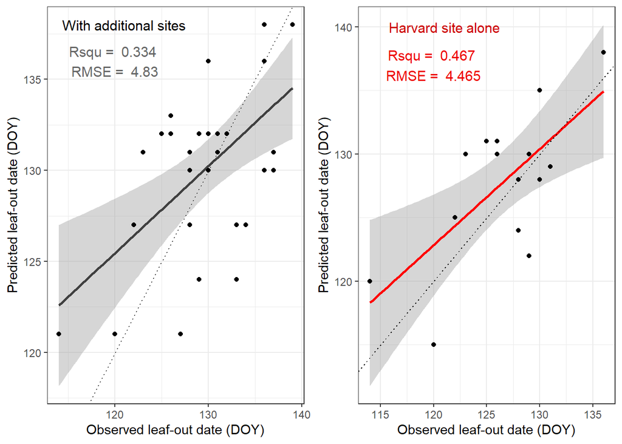

At first glance, the addition of sites has not improved the model skill, with a decreased Rsquared value (less predictive skill) and a worse RMSE (worse model fit) compared to Harvard alone. This also becomes apparent visually with a further deviation from the model fit line from the diagonal.

**Spatial Scaling**

Download daily DAYMET data to scale the model spatially:

```r
# Download daily data
daymetr::download_daymet_tiles(
  tiles = 11935,
  start = 2012,
  end = 2012,
  param = c("tmin","tmax"),
  path = paste0(here::here(), "/data/"),
  silent = TRUE
)

# calculate the daily mean values
r <- daymetr::daymet_grid_tmean(
  path = paste0(here::here(), "/data/"),
  year=2012,
  product = 11935,
  internal = TRUE
)

# reproject to lat lon
r <- terra::project(
  r,
  "+init=epsg:4326"
)

# subset to first 180 days
ma_nh_temp <- terra::subset(
  r,
  1:180
)

#can then apply the model to this raster (cube) using the the terra::app() function
predicted_phenology <- terra::app(
  ma_nh_temp,
  fun = gdd_model,
  par = optim_par
)
```

plotting the results:

[interactive chart not shown]

Fig. 2: Interactive map of the spatially scaled optimized model using DAYMET daily mean temperature data fro tile 11935, including the greater Boston area for the year 2012